# **END INFANT MALNUTRITION**

Author

*Juliet Healy*

[figure not shown]

maxresdefault.jpg

Only *32%* of Infants in the World Consume a Diverse Diet!

Malnutrition in Infants causes *severe* long-lasting and sometimes *irreversible* impacts.

These impacts can include:

- Stunted Growth
- Weakened Immune System
- Impacted Brain Development
- Reduced Motor Skills
- Disease
- Mortality

The Map below shows the percentage of Infants (6-23 months) who meet the minimun diet diversity standards per country.

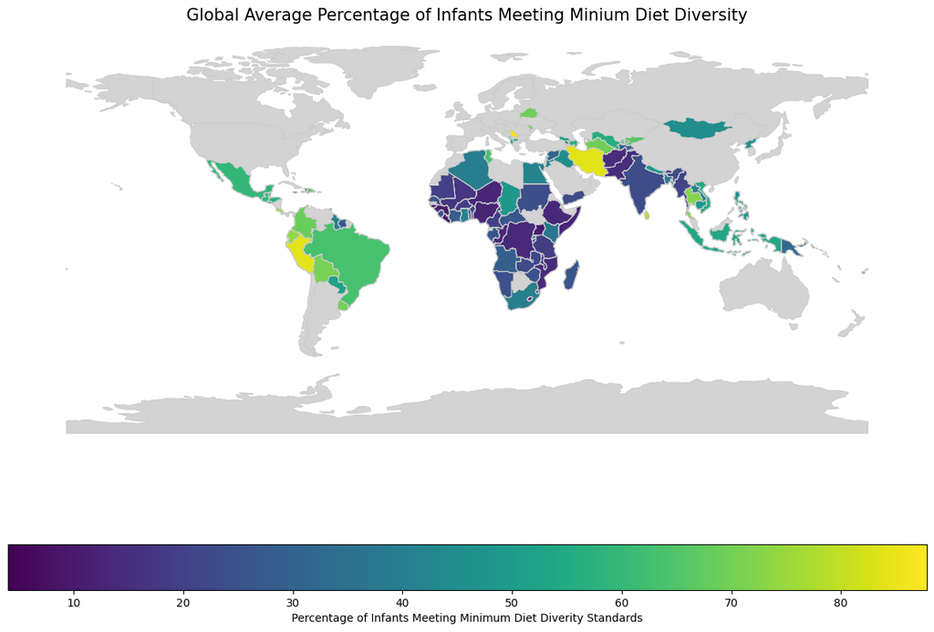

```python
import pandas as pd
import geopandas as gpd
import matplotlib.pyplot as plt

indicator_df = pd.read_csv("unicef_indicator_1.csv")
metadata_df = pd.read_csv("unicef_metadata.csv")

url = "https://naturalearth.s3.amazonaws.com/110m_cultural/ne_110m_admin_0_countries.zip"
world = gpd.read_file(url)

world = world.rename(columns={'SOV_A3': 'alpha_3_code'})

indicator_df = indicator_df.rename(columns={
    'CountryCode': 'iso_a3',
    'Value': 'value'
})

merged = world.merge(
    indicator_df,
    left_on='alpha_3_code',
    right_on='alpha_3_code',
    how='left'
)

fig, ax = plt.subplots(1, 1, figsize=(15, 10))
merged.plot(
    column='obs_value',
    cmap='viridis',
    linewidth=0.8,
    ax=ax,
    edgecolor='0.8',
    legend=True,
    legend_kwds={'label': "Percentage of Infants Meeting Minimum Diet Diverity Standards", 'orientation': "horizontal"},
    missing_kwds={
        "color": "lightgrey",
        "label": "Missing values"
    }
)
ax.set_title("Global Average Percentage of Infants Meeting Minium Diet Diversity", fontsize=15)
ax.set_axis_off()
plt.show()
```

Every Infant and Child has the **RIGHT** to good nutrition according to the

“Convention on the Rights of the Child”

UNICEF supplies nearly **80%** of the world’s *therapeutic food*.

*Therapeutic food* - a life-saving nutrient-rich paste - can pull a malnourished child back from the brink of death in just weeks.

Good Nutrition is vital.

The Bar Chart below shows the 10 **best** countries for meeting Infant Diet Diversity Standards.

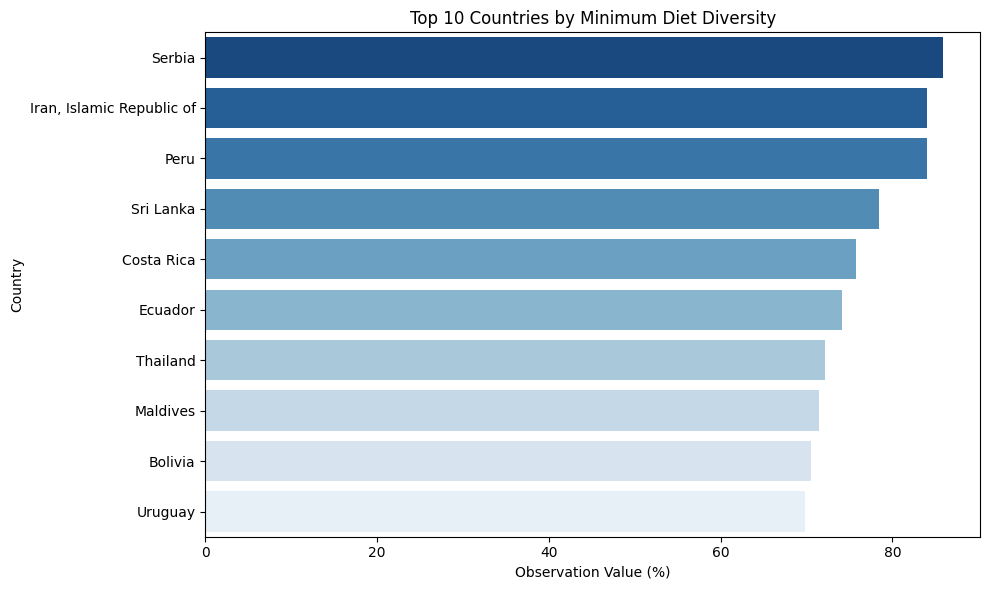

```python
import pandas as pd
import matplotlib.pyplot as plt
import seaborn as sns

df = pd.read_csv('unicef_indicator_1.csv')
df_total = df[df['sex'] == 'Total'].copy()
df_total['year_numeric'] = df_total['time_period'].str[:4].astype(int)
top_10 = df_total.loc[df_total.groupby('country')['year_numeric'].idxmax()].sort_values('obs_value', ascending=False).head(10)

plt.figure(figsize=(10, 6))
sns.barplot(data=top_10, x='obs_value', y='country', palette='Blues_r')
plt.title('Top 10 Countries by Minimum Diet Diversity')
plt.xlabel('Observation Value (%)')
plt.ylabel('Country')

plt.tight_layout()
plt.show()
```

**GDP per capita** has a significant, direct impact on nutrition, with higher levels generally associated with improved food availability, diet diversity, and better nutritional outcomes. As a country’s economic output per person increases, so does its ability to access a greater variety and quantity of food, particularly proteins, vitamins, and minerals.

The Scatterplot below shows the *correlation* between GDP per capita and nutrition across several countries.

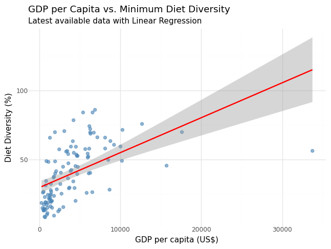

```python
import pandas as pd
from plotnine import ggplot, aes, geom_point, geom_smooth, labs, theme_minimal

indicator_df = pd.read_csv('unicef_indicator_1.csv')
metadata_df = pd.read_csv('unicef_metadata.csv')

indicator_df = indicator_df[indicator_df['sex'] == 'Total'].copy()
indicator_df['year'] = indicator_df['time_period'].str[:4].astype(int)

idx = indicator_df.groupby('country')['year'].idxmax()
indicator_latest = indicator_df.loc[idx]

merged_df = pd.merge(
    indicator_latest,
    metadata_df,
    on=['alpha_3_code', 'year'],
    how='inner'
)

plot_df = merged_df.rename(columns={
    'GDP per capita (constant 2015 US$)': 'GDP_capita',
    'obs_value': 'Diet_Diversity'
}).dropna(subset=['GDP_capita', 'Diet_Diversity'])

p = (
    ggplot(plot_df, aes(x='GDP_capita', y='Diet_Diversity'))
    + geom_point(alpha=0.6, color='steelblue', size=2)
    + geom_smooth(method='lm', color='red', size=1)
    + labs(
        title='GDP per Capita vs. Minimum Diet Diversity',
        subtitle='Latest available data with Linear Regression',
        x='GDP per capita (US$)',
        y='Diet Diversity (%)'
    )
    + theme_minimal()
)
p.draw(show=True)

print(p)
```

The time-series chart below shows the two countries with the *lowest* rates of Infants meeting diet diversity standards (Ethiopia & Guinnea).

It also shows the two countries with the *highest* rates (Islamic Republic of Iran and Serbia).

It also shows that life expectancy is *increasing* for all four countries. Better health care and hygiene, healthier life styles, sufficient food and improved medical care and reduced child mortality have contributed to this. This is why the work of **UNICEF** is so important.

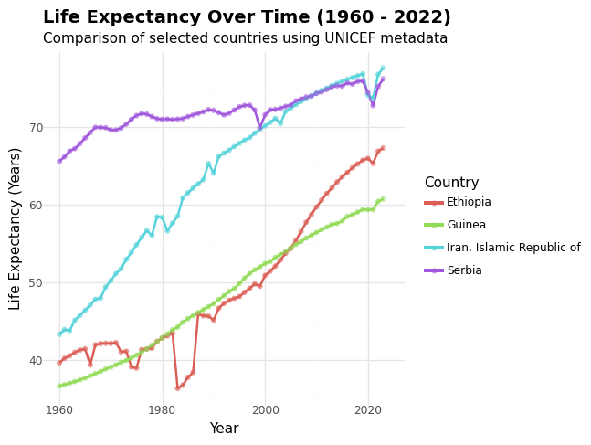

```python
import pandas as pd
from plotnine import ggplot, aes, geom_line, geom_point, labs, theme_minimal, theme, element_text

df = pd.read_csv('unicef_metadata.csv')

selected_countries = ['Guinea', 'Ethiopia', 'Serbia', 'Iran, Islamic Republic of']
df_filtered = df[df['country'].isin(selected_countries)].copy()

df_filtered = df_filtered.sort_values(by=['country', 'year'])

p = (
    ggplot(df_filtered, aes(x='year', y='Life expectancy at birth, total (years)', color='country'))
    + geom_line(size=1)
    + geom_point(size=1.5, alpha=0.5)
    + labs(
        title='Life Expectancy Over Time (1960 - 2022)',
        subtitle='Comparison of selected countries using UNICEF metadata',
        x='Year',
        y='Life Expectancy (Years)',
        color='Country'
    )
    + theme_minimal()
    + theme(
        plot_title=element_text(size=14, weight='bold'),
        legend_position='right'
    )
)
p.draw(show=True)
print(p)
```

Children who receive the **right** nutrition at the **right** time in their development, particularly during the first two years of life are more likely to survive, grow and develop to their **full potential**.

**Global efforts** to reduce mortality are having an **impact**, averting more child deaths from malnutrition than ever before. In fact, the global under-5 mortality rate has declined by 51% since 2000.

**UNICEF** has been working to highlight the magnitude of the nutrition crisis.

In 2023, **UNICEF** reached 9.3 million children with life-saving treatment for severe wasting.

**Donations to UNICEF can change lives for the better!**